# DA_analysis_archR

### Evaluate the consistency between clusters and cell type labels from RNA data

The unsupervised clustering results on chromatin accessibility data shows overall consistency with cell type labels obtained from scRNA-seq data.

**A summary table for the most represented cell type and its percentage in each cluster**

A data.frame: 2 × 17

|  | C1 <chr> | C10 <chr> | C11 <chr> | C12 <chr> | C13 <chr> | C14 <chr> | C15 <chr> | C16 <chr> | C17 <chr> | C2 <chr> | C3 <chr> | C4 <chr> | C5 <chr> | C6 <chr> | C7 <chr> | C8 <chr> | C9 <chr> |
| --- | --- | --- | --- | --- | --- | --- | --- | --- | --- | --- | --- | --- | --- | --- | --- | --- | --- |
| cell type | Classical_monocytes | T_cells | T_cells | Memory_B_cells | T_cells | T_cells | T_cells | CD16_pos_NK_cells | CD16_neg_NK_cells | Naive_B_cells | Naive_B_cells | Memory_B_cells | Memory_B_cells | Classical_monocytes | T_cells | T_cells | T_cells |
| percentage | 0.94 | 0.92 | 0.92 | 0.69 | 0.86 | 0.73 | 0.89 | 0.84 | 0.44 | 0.65 | 0.84 | 0.93 | 0.99 | 0.39 | 0.95 | 0.88 | 0.92 |

**Barplots to visualize cell type composition in each cluster**

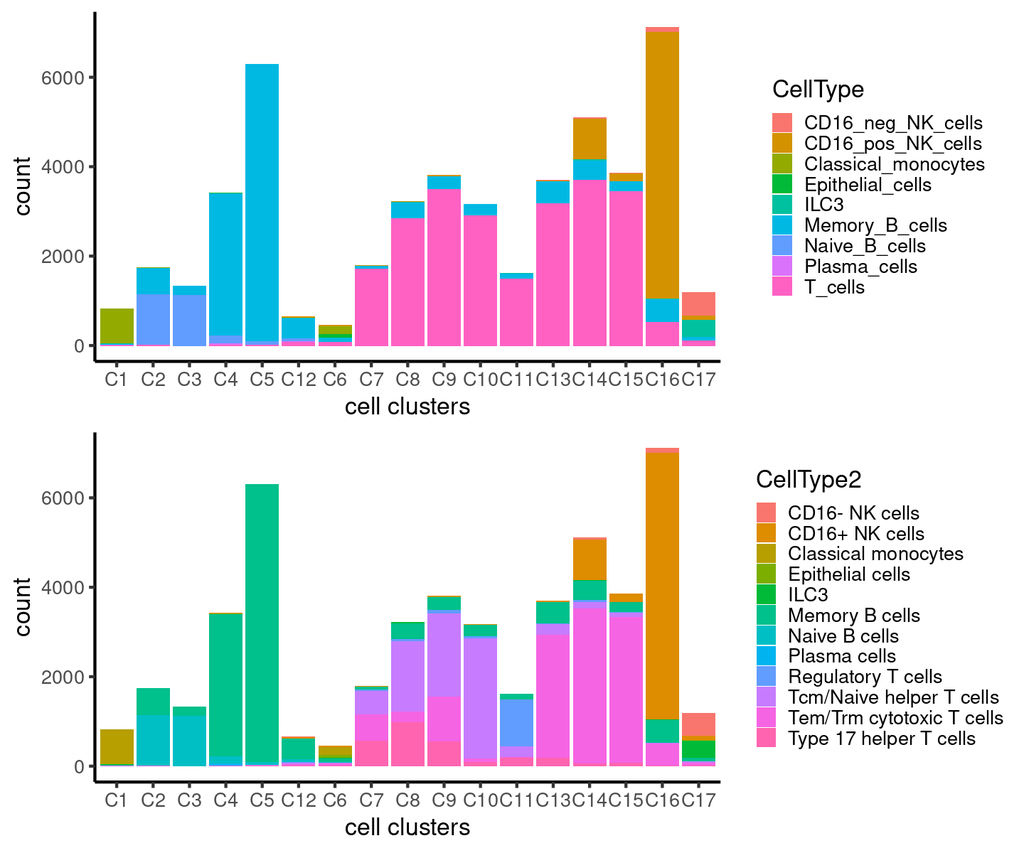

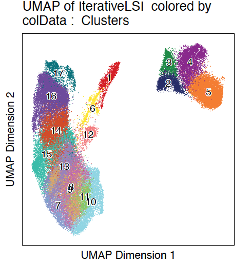

### Cell compositions across immune cell types

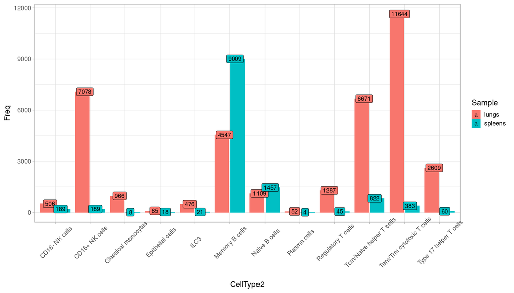

## 5 Peak calling

- Make pseudobulk replicates by adding group coverages for each cell type
- Call peaks using MACS2
- Quantify reads in peaks

Note: no unusual symbols shall be included in the group names, otherwise no hdf5 file can be found.

### Peak abundance comparison with current snATAC-seq dataset

Peak numbers for all cells from our own dataset

A tibble: 10 × 2

| Group <chr> | sum <dbl> |
| --- | --- |
| CD16_neg_NK_cells(n = 695) | 54171 |
| CD16_pos_NK_cells(n = 7267) | 51859 |
| Classical_monocytes(n = 974) | 38549 |
| Epithelial_cells(n = 103) | 20484 |
| ILC3(n = 497) | 30863 |
| Memory_B_cells(n = 13556) | 58948 |
| Naive_B_cells(n = 2566) | 67457 |
| Plasma_cells(n = 56) | 24367 |
| T_cells(n = 23521) | 61570 |
| UnionPeaks | 120676 |

Peaks numbers for T cells alone from our dataset

```r
projT@peakSet@metadata$PeakCallSummary %>% group_by(Group) %>% summarise(sum=sum(Freq)*1000)
```

A tibble: 5 × 2

| Group <chr> | sum <dbl> |
| --- | --- |
| Regulatory T cells(n = 1332) | 27953 |
| Tcm/Naive helper T cells(n = 7493) | 64650 |
| Tem/Trm cytotoxic T cells(n = 12027) | 51287 |
| Type 17 helper T cells(n = 2669) | 33236 |
| UnionPeaks | 75099 |

Peak numbers from *Wang et al.*

A data.frame: 3 × 4

| cell_type <chr> | Wang2020 <chr> | u19_dataset <chr> | percent_increase <chr> |
| --- | --- | --- | --- |
| B_cells | 52100 | 67457 | 29% |
| T_cells | 56732 | 61570 | 9% |
| natural_killer_cells | 48730 | 54171 | 11% |

## 6 Differential accessibility analysis by cell types

DA analysis in ArchR adjusts for TSS enrichment and number of unique fragments per cell.

### Heatmaps for DA z-scores

computed by comparing each cell type against the rest

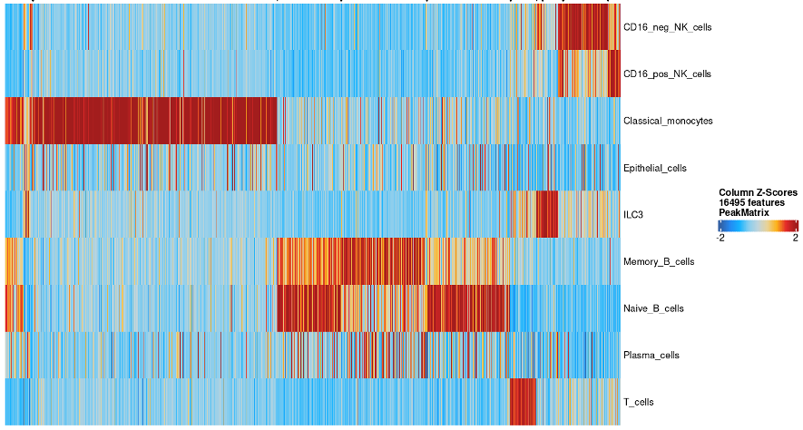

Heatmap DA results including T cell subsets

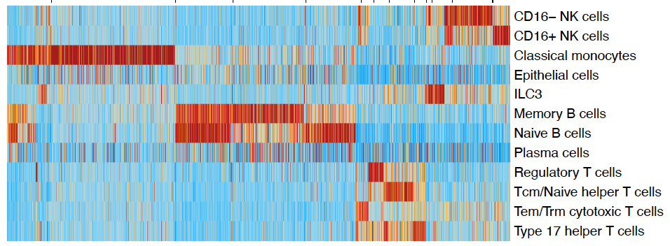

```r
enrichMotifs
```

```
class: SummarizedExperiment
dim: 870 12
metadata(0):
assays(10): mlog10Padj mlog10p ... CompareFrequency feature
rownames(870): TFAP2B_1 TFAP2D_2 ... TBX18_869 TBX22_870
rowData names(0):
colnames(12): CD16- NK cells CD16+ NK cells ... Tem/Trm cytotoxic T
  cells Type 17 helper T cells
colData names(0):
```

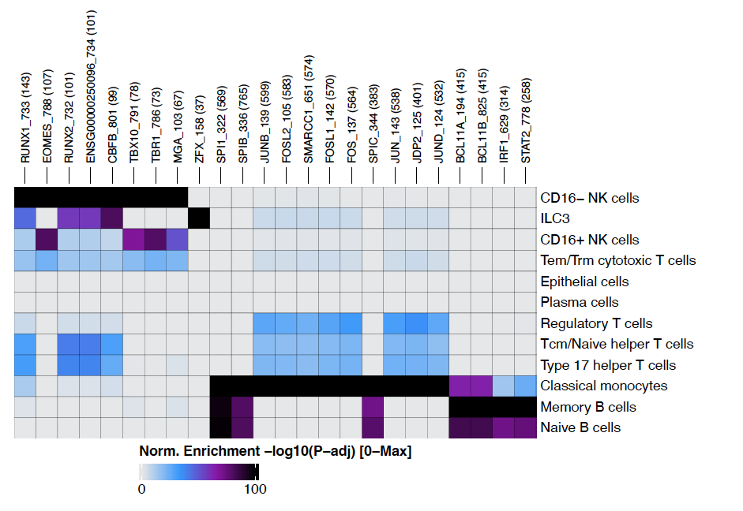

## 7 Differential accessibility analysis between tissues

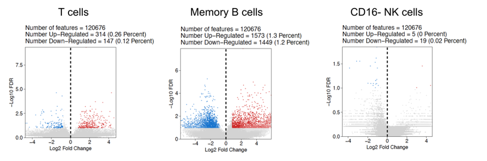

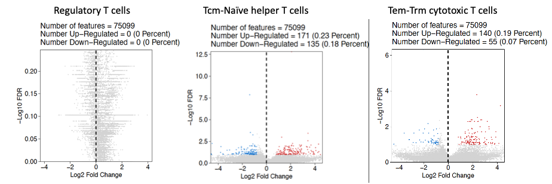

### Motif analysis for DA peaks across tissues

```r
enrichMotifs
```

```
class: SummarizedExperiment
dim: 870 1
metadata(0):
assays(10): mlog10Padj mlog10p ... CompareFrequency feature
rownames(870): TFAP2B_1 TFAP2D_2 ... TBX18_869 TBX22_870
rowData names(0):
colnames(1): lungs-Tem/Trm cytotoxic T cells
colData names(0):
```

[output not shown]

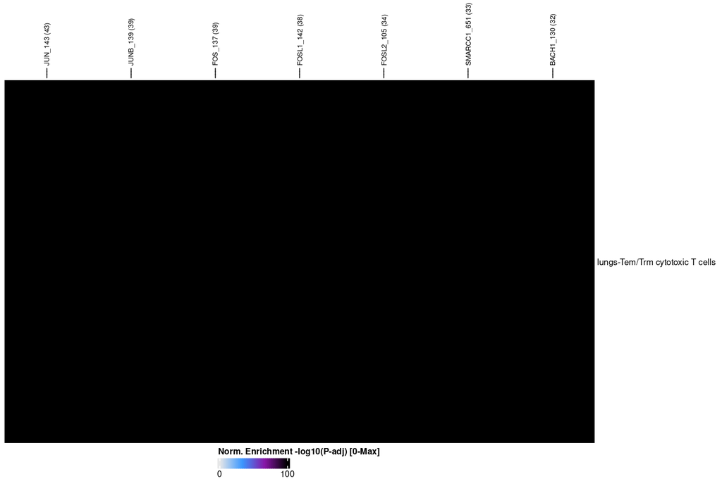

```r
heatmapEM <- plotEnrichHeatmap(enrichMotifs, n = 7, transpose = TRUE)
ComplexHeatmap::draw(heatmapEM, heatmap_legend_side = "bot", annotation_legend_side = "bot")
```